# Exploring and Summarizing Data

Authors

Casey Schine

adapted from Emily Malcolm-White

```r
#set this to suppress a warning or message when you run a chunk
#| warning: FALSE
#| message: FALSE

#load tidyverse package
library(tidyverse)
```

## `palmerpenguins` dataset

Size measurements, clutch observations, and blood isotope ratios for adult foraging Adélie, Chinstrap, and Gentoo penguins observed on islands in the Palmer Archipelago near Palmer Station, Antarctica. Data were collected and made available by Dr. Kristen Gorman and the Palmer Station Long Term Ecological Research (LTER) Program.

```r
#load data
library(palmerpenguins)
data(penguins)
```

**Let’s take a quick look at the data that we just loaded.**

```r
# give me some ideas for how to do this
```

**With a partner or in groups answer**

What does a single row represent in each of the loaded datasets?

What is the difference between the two datasets?

## `drop_na()`

`drop_na()` removes rows with missing data. If you use it with no additional arguments it will drop a row that contains an `NA` in any column.

```r
# save as new object
# drop_na without pipe

penguins_mod <- drop_na(penguins)

# drop_na with pipe

penguins_mod <- penguins |>
  drop_na()
```

**Warning**

Is it appropriate to remove rows with missing data? How many rows have missing data? Do the missing rows have something in common?

Removing rows can affect the validity and generalizability of your analysis!

What is the difference between `pengiuns` and `penguins_mod`?

```r
#use nrow on penguins and penguins_mod without pipe

nrow(penguins)
```

```
[1] 344
```

```r
nrow(penguins_mod)
```

```
[1] 333
```

```r
#same with pipe

penguins |>
  nrow()
```

```
[1] 344
```

```r
penguins_mod |>
  nrow()
```

```
[1] 333
```

So, weve lost 11 rows? **Where did we loose them from?** Did we actually want to remove those rows?

```r
# where do you think we lost the rows from?

# Here is how we can take a better look at just those rows using filter()

penguins |>
  filter(is.na(bill_length_mm))
```

```
# A tibble: 2 × 8
  species island    bill_length_mm bill_depth_mm flipper_length_mm body_mass_g
  <fct>   <fct>              <dbl>         <dbl>             <int>       <int>
1 Adelie  Torgersen             NA            NA                NA          NA
2 Gentoo  Biscoe                NA            NA                NA          NA
# ℹ 2 more variables: sex <fct>, year <int>
```

```r
penguins |>
  filter(is.na(sex))
```

```
# A tibble: 11 × 8
   species island    bill_length_mm bill_depth_mm flipper_length_mm body_mass_g
   <fct>   <fct>              <dbl>         <dbl>             <int>       <int>
 1 Adelie  Torgersen           NA            NA                  NA          NA
 2 Adelie  Torgersen           34.1          18.1               193        3475
 3 Adelie  Torgersen           42            20.2               190        4250
 4 Adelie  Torgersen           37.8          17.1               186        3300
 5 Adelie  Torgersen           37.8          17.3               180        3700
 6 Adelie  Dream               37.5          18.9               179        2975
 7 Gentoo  Biscoe              44.5          14.3               216        4100
 8 Gentoo  Biscoe              46.2          14.4               214        4650
 9 Gentoo  Biscoe              47.3          13.8               216        4725
10 Gentoo  Biscoe              44.5          15.7               217        4875
11 Gentoo  Biscoe              NA            NA                  NA          NA
# ℹ 2 more variables: sex <fct>, year <int>
```

```r
# to find out where NAs are
summary(penguins)
```

```
      species          island    bill_length_mm  bill_depth_mm
 Adelie   :152   Biscoe   :168   Min.   :32.10   Min.   :13.10
 Chinstrap: 68   Dream    :124   1st Qu.:39.23   1st Qu.:15.60
 Gentoo   :124   Torgersen: 52   Median :44.45   Median :17.30
                                 Mean   :43.92   Mean   :17.15
                                 3rd Qu.:48.50   3rd Qu.:18.70
                                 Max.   :59.60   Max.   :21.50
                                 NA's   :2       NA's   :2
 flipper_length_mm  body_mass_g       sex           year
 Min.   :172.0     Min.   :2700   female:165   Min.   :2007
 1st Qu.:190.0     1st Qu.:3550   male  :168   1st Qu.:2007
 Median :197.0     Median :4050   NA's  : 11   Median :2008
 Mean   :200.9     Mean   :4202                Mean   :2008
 3rd Qu.:213.0     3rd Qu.:4750                3rd Qu.:2009
 Max.   :231.0     Max.   :6300                Max.   :2009
 NA's   :2         NA's   :2
```

```r
penguins |>
  summary()
```

```
      species          island    bill_length_mm  bill_depth_mm
 Adelie   :152   Biscoe   :168   Min.   :32.10   Min.   :13.10
 Chinstrap: 68   Dream    :124   1st Qu.:39.23   1st Qu.:15.60
 Gentoo   :124   Torgersen: 52   Median :44.45   Median :17.30
                                 Mean   :43.92   Mean   :17.15
                                 3rd Qu.:48.50   3rd Qu.:18.70
                                 Max.   :59.60   Max.   :21.50
                                 NA's   :2       NA's   :2
 flipper_length_mm  body_mass_g       sex           year
 Min.   :172.0     Min.   :2700   female:165   Min.   :2007
 1st Qu.:190.0     1st Qu.:3550   male  :168   1st Qu.:2007
 Median :197.0     Median :4050   NA's  : 11   Median :2008
 Mean   :200.9     Mean   :4202                Mean   :2008
 3rd Qu.:213.0     3rd Qu.:4750                3rd Qu.:2009
 Max.   :231.0     Max.   :6300                Max.   :2009
 NA's   :2         NA's   :2
```

What questions would we need to remove `NA` rows in order to answer?

What questions could we answer without removing `NA` rows? Or which `NA` rows would we remove and which could we leave?

## `count()`

`count()` lets you quickly count the unique values of one or more variables. Suppose you want the number of penguins on each island.

```r
# use only count for island

penguins |>
  count()
```

```
# A tibble: 1 × 1
      n
  <int>
1   344
```

```r
penguins |>
  count(island)
```

```
# A tibble: 3 × 2
  island        n
  <fct>     <int>
1 Biscoe      168
2 Dream       124
3 Torgersen    52
```

```r
penguins |>
  count(species)
```

```
# A tibble: 3 × 2
  species       n
  <fct>     <int>
1 Adelie      152
2 Chinstrap    68
3 Gentoo      124
```

Or the number of each species on each island.

```r
# use count for island, species

penguins |>
  count(island, species)
```

```
# A tibble: 5 × 3
  island    species       n
  <fct>     <fct>     <int>
1 Biscoe    Adelie       44
2 Biscoe    Gentoo      124
3 Dream     Adelie       56
4 Dream     Chinstrap    68
5 Torgersen Adelie       52
```

Or the number of each sex of each species on each island.

```r
# use count for island, species, sex

penguins |>
  count(island, species, sex)
```

```
# A tibble: 13 × 4
   island    species   sex        n
   <fct>     <fct>     <fct>  <int>
 1 Biscoe    Adelie    female    22
 2 Biscoe    Adelie    male      22
 3 Biscoe    Gentoo    female    58
 4 Biscoe    Gentoo    male      61
 5 Biscoe    Gentoo    <NA>       5
 6 Dream     Adelie    female    27
 7 Dream     Adelie    male      28
 8 Dream     Adelie    <NA>       1
 9 Dream     Chinstrap female    34
10 Dream     Chinstrap male      34
11 Torgersen Adelie    female    24
12 Torgersen Adelie    male      23
13 Torgersen Adelie    <NA>       5
```

```r
# has weird NA groupings because sex is sometimes NA
# get a clearer picture after dropping NAs

penguins |>
  drop_na(sex) |>
  count(island, species, sex)
```

```
# A tibble: 10 × 4
   island    species   sex        n
   <fct>     <fct>     <fct>  <int>
 1 Biscoe    Adelie    female    22
 2 Biscoe    Adelie    male      22
 3 Biscoe    Gentoo    female    58
 4 Biscoe    Gentoo    male      61
 5 Dream     Adelie    female    27
 6 Dream     Adelie    male      28
 7 Dream     Chinstrap female    34
 8 Dream     Chinstrap male      34
 9 Torgersen Adelie    female    24
10 Torgersen Adelie    male      23
```

```r
# you can drop the NAs before or after the count
# in some cases (not this one), that could give you different results

penguins |>
  count(island, species, sex) |>
  drop_na(sex)
```

```
# A tibble: 10 × 4
   island    species   sex        n
   <fct>     <fct>     <fct>  <int>
 1 Biscoe    Adelie    female    22
 2 Biscoe    Adelie    male      22
 3 Biscoe    Gentoo    female    58
 4 Biscoe    Gentoo    male      61
 5 Dream     Adelie    female    27
 6 Dream     Adelie    male      28
 7 Dream     Chinstrap female    34
 8 Dream     Chinstrap male      34
 9 Torgersen Adelie    female    24
10 Torgersen Adelie    male      23
```

## `summarize()` or `summarise()` (either works)

Suppose we are interested in the average bill length of all Adelie penguins.

```r
# use summarize for average bill length in Adelie penguins
# Do it first without removing NAs

penguins |>
  filter(species=="Adelie") |>
  summarize(mean(bill_length_mm))
```

```
# A tibble: 1 × 1
  `mean(bill_length_mm)`
                   <dbl>
1                     NA
```

```r
# have to deal with the NAs

penguins |>
  filter(species=="Adelie") |>
  summarize(mean(bill_length_mm, na.rm=TRUE))
```

```
# A tibble: 1 × 1
  `mean(bill_length_mm, na.rm = TRUE)`
                                 <dbl>
1                                 38.8
```

```r
# Then remove NAs using na.rm=TRUE


penguins |>
  filter(species=="Adelie") |>
  drop_na(bill_length_mm)  |>
  summarize(mean(bill_length_mm))
```

```
# A tibble: 1 × 1
  `mean(bill_length_mm)`
                   <dbl>
1                   38.8
```

```r
penguins |>
  filter(species=="Adelie") |>
  drop_na() |>
  summarize(mean(bill_length_mm))
```

```
# A tibble: 1 × 1
  `mean(bill_length_mm)`
                   <dbl>
1                   38.8
```

Suppose we are interested in the average bill length AND average bill depth of all Adelie penguins:

```r
# calculate average bill length and average bill depth for Adelie
# filter for Adelie then summarize

penguins |>
  filter(species=="Adelie") |>
  summarize(mean(bill_length_mm, na.rm=TRUE),
            mean(bill_depth_mm, na.rm=TRUE))
```

```
# A tibble: 1 × 2
  `mean(bill_length_mm, na.rm = TRUE)` `mean(bill_depth_mm, na.rm = TRUE)`
                                 <dbl>                               <dbl>
1                                 38.8                                18.3
```

There are lots of other functions available:

- `min`: minimum value
- `max`: maximum value
- `mean`: average or mean value
- `median`: median value
- `var`: variance
- `sd`: standard deviation
- `n`: count or number of values
- `n_distinct`: counts number of distinct values

Suppose we are interested in the average bill length AND the median bill length of all Adelie penguins:

```r
# filter for Adelie and summarise (but change to median)
# average bill length and MEDIAN bill length

penguins |>
  filter(species=="Adelie") |>
  summarize(mean(bill_length_mm, na.rm=TRUE),
            median(bill_length_mm, na.rm=TRUE),
            n())
```

```
# A tibble: 1 × 3
  `mean(bill_length_mm, na.rm = TRUE)` median(bill_length_mm, na.rm = TR…¹ `n()`
                                 <dbl>                               <dbl> <int>
1                                 38.8                                38.8   152
# ℹ abbreviated name: ¹`median(bill_length_mm, na.rm = TRUE)`
```

```r
penguins |>
  filter(species=="Adelie") |>
  drop_na(bill_length_mm) |>
  summarize(mean(bill_length_mm),
            median(bill_length_mm),
            n())
```

```
# A tibble: 1 × 3
  `mean(bill_length_mm)` `median(bill_length_mm)` `n()`
                   <dbl>                    <dbl> <int>
1                   38.8                     38.8   151
```

```r
penguins |>
  filter(species=="Adelie") |>
  summarize(n())
```

```
# A tibble: 1 × 1
  `n()`
  <int>
1   152
```

We can also give the new calculated variables names of our choosing rather than letting R makes choices, because it does the wackiest stuff when left to its’ own devices.

```r
# # filter for Adelie and summarise (but change to median)
# average bill length and MEDIAN bill length
# AND name the new variables created in summarize rather than having the names generated automatically

penguins |>
  filter(species=="Adelie") |>
  drop_na(bill_length_mm) |>
  summarize(mean_bill_length=mean(bill_length_mm),
            median_bill_length=median(bill_length_mm),
            count=n())
```

```
# A tibble: 1 × 3
  mean_bill_length median_bill_length count
             <dbl>              <dbl> <int>
1             38.8               38.8   151
```

```r
adelie_summary <- penguins |>
  filter(species=="Adelie") |>
  drop_na(bill_length_mm) |>
  summarize(mean_bill_length=mean(bill_length_mm),
            median_bill_length=median(bill_length_mm),
            count=n())


adelie_summary <- penguins |>
  filter(species=="Adelie") |>
  drop_na(bill_length_mm) |>
  summarize(mean_bill_length=mean(bill_length_mm)) |>
  pull(mean_bill_length)

  adelie_summary + 40
```

```
[1] 78.79139
```

## `group_by()`

Let’s say we were interested in the average bill length and bill depth of all penguin species in this dataset. We could repeat this for the other species (Gentoo and Chinstrap). This would be a fair amount of work AND the results would not end up in the same table.

OR we could use the `group_by` command!

```r
# group_by species and then summarize bill length and bill depth (mean)


penguins |>
  group_by(species) |>
  drop_na(bill_length_mm) |>
  summarize(mean_bill_length=mean(bill_length_mm),
            mean_bill_depth=mean(bill_depth_mm))
```

```
# A tibble: 3 × 3
  species   mean_bill_length mean_bill_depth
  <fct>                <dbl>           <dbl>
1 Adelie                38.8            18.3
2 Chinstrap             48.8            18.4
3 Gentoo                47.5            15.0
```

```r
penguins |>
  group_by(island) |>
  drop_na(bill_length_mm) |>
  summarize(mean_bill_length=mean(bill_length_mm),
            mean_bill_depth=mean(bill_depth_mm))
```

```
# A tibble: 3 × 3
  island    mean_bill_length mean_bill_depth
  <fct>                <dbl>           <dbl>
1 Biscoe                45.3            15.9
2 Dream                 44.2            18.3
3 Torgersen             39.0            18.4
```

### Multiple Groups

Suppose we wish to have the average bill length and average bill depth broken down by sex AND species:

```r
# group by species/sex and then summarize avg bill depth

penguins |>
  group_by(species, sex) |>
  drop_na() |>
  summarize(mean_bill_length=mean(bill_length_mm),
            mean_bill_depth=mean(bill_depth_mm))
```

```
# A tibble: 6 × 4
# Groups:   species [3]
  species   sex    mean_bill_length mean_bill_depth
  <fct>     <fct>             <dbl>           <dbl>
1 Adelie    female             37.3            17.6
2 Adelie    male               40.4            19.1
3 Chinstrap female             46.6            17.6
4 Chinstrap male               51.1            19.3
5 Gentoo    female             45.6            14.2
6 Gentoo    male               49.5            15.7
```

```r
# do it first without filtering out NAs

# do it again with NAs removed
```

We can also give the new calculated variables names of our choosing rather than letting R makes choices, because it does the wackiest stuff when left to its’ own devices.

## `mutate()`

`mutate()` creates new columns that are functions of existing variables.

```r
# first just create a new column that contains all 5s

penguins_mod <- penguins |>
  mutate(fives=5)
```

For example, let’s calculate create a new column which displays the body length weight in pounds (lbs) instead of grams. Recall: to convert from grams to pounds we need to multiply by 0.00220462.

```r
# calculate body mass in lb from conversion factor (0.00220462 lb/g), create new column

penguins_mod <- penguins |>
  mutate(body_mass_lb=body_mass_g*0.00220462)


# then assign it to new object
```

This can be useful for unit conversions. It also be useful for making new calculations based on existing data, for example, the ratio of `bill_length` to `bill_depth`.

```r
penguins_mod <- penguins_mod |>
  mutate(bill_ratio = bill_depth_mm/bill_length_mm)
```

## `case_when()`

Case when can be used in combination with `mutate` to create a new column with a categorical variable conditional on the values in another column.

For example:

```r
# penguins <- penguins |>
#   mutate(penguin_length_cat = case_when(bill_length_mm > 50 ~ 'whoa! huge bill!', TRUE ~ '--' ))

# make a new column with a single letter for each penguin species

penguins_mod <- penguins_mod |>
  mutate(spp_abbr = case_when(species=="Adelie" ~ "A",
                              species=="Gentoo" ~ "G",
                              species == "Chinstrap" ~ "C"))


# make a new column with a body mass cutoff that labels penguins below the cutoff as "little" and the ones above it as "BIG"

penguins_mod <- penguins_mod |>
  mutate(size = case_when(body_mass_g >= 5000 ~ "BIG",
                          body_mass_g < 5000 ~ "little"))
```

# Penguin Data Story

I love to play around with data and find little stories, which is what I will be asking you to do more and more as we move through the course material. So I had a little fun with the `palmerpenguins` data and this is what I came up with.

Now let’s look at the `penguins_raw` version of the data. There are a bunch more variables and below is an example of what you will be able to do by the end of next week.

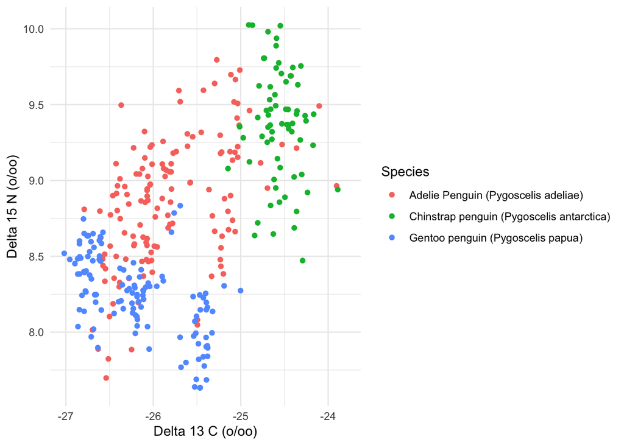

```r
penguins_raw |>
  ggplot() +
  geom_point(aes(x=`Delta 13 C (o/oo)`, y=`Delta 15 N (o/oo)`, color=Species)) +
  theme_minimal()
```

This first plot shows the 15N isotopic ratio on the y-axis plotted against the 13C isotopic ratio on the x-axis. This first plot shows the points colored by species.

**What do you see?**

What is plotted? (axes, units, scale, type of plot)

How is information encoded? (color, size, shape)

What patterns are visually undeniable (trends, clusters, gradients, discontinuities)?

What do you think this figure shows?

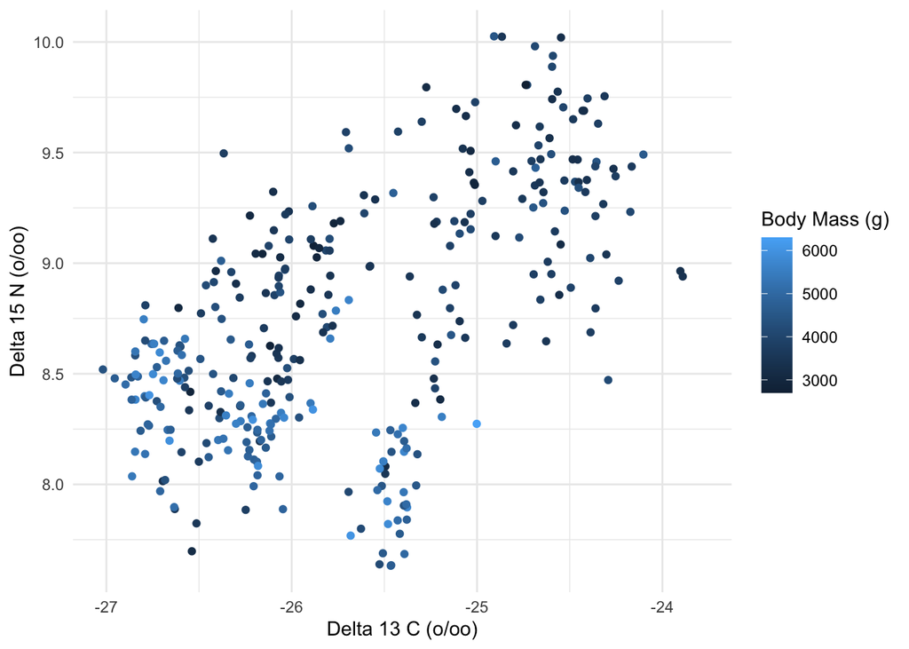

```r
penguins_raw |>
  ggplot() +
  geom_point(aes(x=`Delta 13 C (o/oo)`, y=`Delta 15 N (o/oo)`, color=`Body Mass (g)`)) +
  theme_minimal()
```

This second plot has the same x and y axes as the first plot, but now the points are colored by body mass.

What do you see? *(refer to the tip box above)*

If we then look at the distribution of body mass for each species in a boxplot:

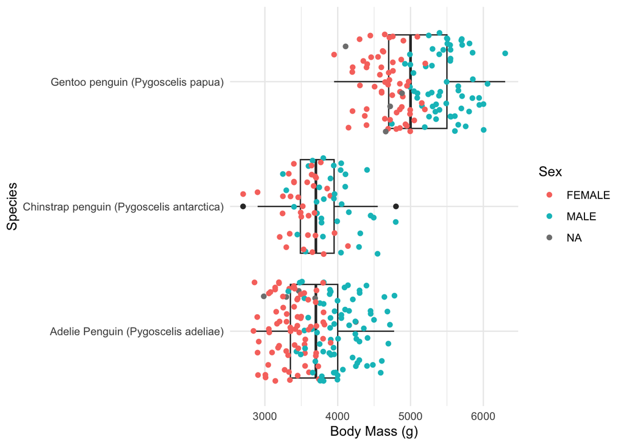

```r
penguins_raw |>
  ggplot(aes(y=Species, x=`Body Mass (g)`)) +
  geom_boxplot() +
  geom_jitter(aes(color=Sex)) +
  theme_minimal()
```

What do you see? *(refer to the tip box above)*

What questions do these figures raise for you? What would you want to look at next?